# Sample Rmarkdown

Asako Mikami

February 11, 2019

Abstract

This document demonstrates how to weave and execute R codes within an Rmarkdown document with `knitr`. The first section runs a simulation of simultaneous relationship. The second section runs a logistic regression model and displays the result table using the `xtable` and `stargazer` package. The output is available as both `.pdf` and `.html` documents. To render a `pdf` document, run `rmarkdown::render('sample-ta.Rmd', 'pdf_document', params = list(input_type = 'latex))`. To render an `.html` document, run `rmarkdown::render('sample-ta.Rmd', 'html_document', params = list(input_type = 'html'))`.

```r
# load library
x <- c("dplyr", "purrr", "stargazer", "RColorBrewer", "knitr",
       "xtable")
lapply(x, library, character.only = TRUE, quietly = TRUE)

# set up color palette to be used in this document
color <- brewer.pal(3, "Paired")
```

```r
# For this document, I want to show most of the R source code,
# so I am setting the global option `echo = TRUE`.
#-----------------
# I want to save my plot outputs as png and pdf files with
# transparent backgroun din the `fig` folder:
# `fig.path = "fig/", dev = c("png", "pdf"),
# dev.args = list(bg = "transparent")`
#-----------------
# When the plot is displayed in the document, I want it to be
# aligned in the center, so I am setting `fig.align = "center"`.
#-----------------
knitr::opts_chunk$set(echo = TRUE,
                      fig.path = "fig/",
                      dev = c("png", "pdf"),
                      dev.args = list(bg = "transparent"),
                      fig.align = "center")
# --------------
# All of these global options can be overwritten in each chunk.
# For example, in section 2, I am hiding some chunks by setting
# `echo = FALSE` in the chunk header.
```

# Simulating simultaneity

Let’s do some simulation of simultaneity.[^1] Suppose we have the following data generating process:
$$\begin{align*}
Y &= \beta X + \epsilon_1, \quad \epsilon_1 \sim N(0, \sigma^2) \\
X &= \alpha Y + \epsilon_2, \quad \epsilon_2 \sim N(0, \tau^2) \\
\epsilon_1 &\perp \epsilon_2
\end{align*}$$
where $\alpha, \beta$ are real constants and $\sigma^2, \tau^2$ are positive constants. Solving this system of equations, we express $Y$ and $X$ free of each other.
$$\begin{align*}
X & = \dfrac{\alpha \epsilon_1 + \epsilon_2}{1 - \alpha\beta} \\
Y & = \dfrac{\epsilon_1 + \beta \epsilon_2}{1- \alpha\beta}
\end{align*}$$
This shows that $X$ and $Y$ are multivariate normal with mean zero. Without any loss of generality, we provide the proof for $\rm{E}[Y] = 0$.
$$\begin{align*}
\rm{E}[Y] & = \rm{E}[\beta X + \epsilon_1] \\
& = \rm{E} \Big[\beta \Big( \dfrac{\alpha \epsilon_1 + \epsilon_2}{1-\alpha \beta} \Big) + \epsilon_1 \Big] \\
& = \dfrac{\beta}{1-\alpha\beta} \rm{E}\Big[\alpha \epsilon_1 + \epsilon_2 \Big] +\rm{E}[\epsilon_1] \\
& = \dfrac{\beta}{1-\alpha\beta} \Big( \alpha\rm{E}[\epsilon_1] + \rm{E}[\epsilon_2] \Big) + \rm{E}[\epsilon_1] \\
&= 0 \quad \text{because $\rm{E}[\epsilon_i] = 0$ for $i=1,2$}
\end{align*}$$
Under this data generating process, the least square estimate $\hat{\beta}$ of linear regression model, $\rm{E}[Y|X] = \beta X$, will be biased.
$$\begin{align*}
\hat{\beta} & = \dfrac{\rm{Cov}(X, Y)}{\rm{Var}(X)} \quad \text{because $X$ is also random variable} \\
& = \dfrac{\rm{E}[XY]}{\rm{Var}(X)} \quad \text{because $\rm{Cov}(X,Y) = \rm{E}[XY]-\rm{E}[X]\rm{E}[Y] = \rm{E}[XY]$} \\
& = \dfrac{\rm{E} \Big[ \Big( \dfrac{\alpha \epsilon_1 + \epsilon_2}{1 - \alpha\beta} \Big)\Big( \dfrac{\epsilon_1 + \beta \epsilon_2}{1- \alpha\beta} \Big) \Big]}{\rm{Var} \Big( \dfrac{\alpha \epsilon_1 + \epsilon_2}{1 - \alpha\beta} \Big)} \\
& = \dfrac{\rm{E}[(\alpha \epsilon_1 + \epsilon_2)(\epsilon_1 + \beta \epsilon_2)]}{\alpha^2 \rm{Var}(\epsilon_1) + \rm{Var}(\epsilon_2)} \quad \text{because $\epsilon_1 \perp \epsilon_2$} \\
& = \dfrac{\rm{E}[\alpha \epsilon_1^2 + (\alpha\beta +1)\epsilon_1 \epsilon_2 + \beta \epsilon_2^2]}{\alpha^2 \rm{Var}(\epsilon_1) + \rm{Var}(\epsilon_2)} \\
& = \dfrac{\alpha\rm{E}(\epsilon_1^2) + (\alpha\beta + 1)\rm{E}[\epsilon_1]\rm{E}[\epsilon_2] + \beta \rm{E}(\epsilon_2)^2}{\alpha^2 \rm{Var}(\epsilon_1) + \rm{Var}(\epsilon_2)} \\
& = \dfrac{\alpha \rm{Var}(\epsilon_1) + \beta \rm{Var}(\epsilon_2)}{\alpha^2 \rm{Var}(\epsilon_1)+\rm{Var}(\epsilon_2)} \quad \text{because $\rm{Var}(\epsilon_i) = \rm{E}[\epsilon_i^2] - \rm{E}[\epsilon_i]^2 = \rm{E}[\epsilon_i^2]$ for $i \in \{1,2\}$} \\
& = \dfrac{\alpha \sigma^2 + \beta \tau^2}{\alpha^2 \sigma^2 + \tau^2} \quad \text{which is generally different from $\beta$}
\end{align*}$$

```r
set.seed(02052019)

# set the parameters
param <- list(beta = sample(2:4, 1),
              alpha = sample(7:9, 1)*-1,
              sigma2 = sample(c(0.3, 1, 1.5), 1),
              tau2 = sample(c(0.2, 1, 1.4), 1),
              n = 500
        )

run_ols <- function(param){
        #---------------------
        # Generates X and Y based on the true data
        # generating process, using the parameters
        # listed in `param`.
        # Output is ols coefficient estimates.
        #---------------------
        # param (a list of parameters)
        #---------------------
        e1 <- rnorm(param$n, mean = 0, sd = param$sigma2)
        e2 <- rnorm(param$n, mean = 0, sd = param$tau2)
        X <- (param$alpha * e1  + e2)/(1 - param$alpha * param$beta)
        Y <- (e1 + param$beta * e2)/(1 - param$alpha * param$beta)
        ols <- lm(Y ~ X - 1) # no intercept
        return(coef(ols))
}

# run simulation and store the result as dataframe
sim <- 9999
library(purrr)
result <- map(seq(sim), ~ run_ols(param)) %>%
        map_dfr(~ as.data.frame(t(as.matrix(.))))
```

Let’s plot the sampling distribution of ols estimates for $\beta$.[^2]

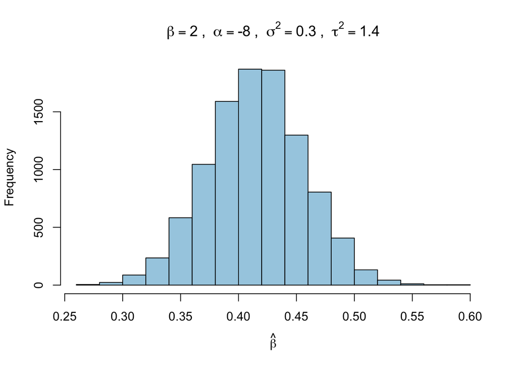

Sampling distribution of OLS estiamtes

```r
# plot the sample distribution of beta.hat
hist(result$X, col = color[1],
     xlab = expression(hat(beta)),
     main = as.expression(bquote(beta==.(param$beta)~", "~
                                  alpha==.(param$alpha)~", "~
                                sigma^2==.(param$sigma2)~", "~
                                tau^2==.(param$tau2)))
     )
```

Let’s simulate across $\beta \in \{0, \pm 0.5, \pm 1.0, \pm 1.5, \pm 2.0\}$, and plot the mean squared error, $(\rm{E}[\hat{\beta}] - \beta)^2$, against $\beta$.

```r
beta <- seq(-2, 2, by = 0.5) # simulation values for beta
sim <- 100
# create a list of parameter lists
param_list <- map(beta, ~update_list(param, beta = .))

run_simulate <- function(param){
        #---------------------------
        # Simulate ols regression for `sim` number of
        # times for each `beta` value.
        # Obtain MSE(beta) of each simulation sample.
        #----------------------------
        # param (a list of parameters)
        #----------------------------

        # generate a sample of ols estimates
        sample <- seq(sim) %>% map(~run_ols(param)) %>%
                map_df(~as.data.frame(.))
        # obtain MSE
        mse <- sample %>% map_df(~(mean(.)-param$beta)^2)
        return(mse)
}

# simulate over `param_list`
ols_mse <- map(param_list, ~run_simulate(.)) %>%
        map_df(~as.data.frame(t(as.matrix(.))))
df <- cbind(beta, ols_mse) # bind with `beta` vector
names(df) <- c("beta", "MSE") # name the columns
```

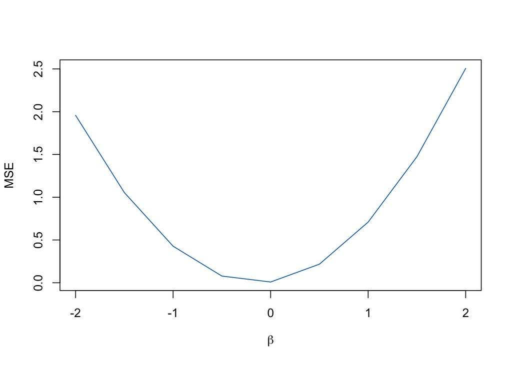

Mean squared error of OLS estimator

```r
# plot MSE against `beta`
plot(MSE ~ beta, data = df, type = "l",
     col = color[2], lwd=1.2,
     xlab = expression(beta))
```

# Bank marketing data set

We have data from a Portugese bank’s telemarketing campaign where the outcome of interest is whethe a client subscribed to a term deposit at the end of the campaign:[^3]
$$Y_i = \begin{cases}
1 & \quad \text{if client $i$ subscribed} \\
0 & \quad \text{otherwise} \end{cases}$$
The code for this section is written in `script/bank-marketing.R` and is printed out in the Appendix.[^4]

We want to model $\pi_i$, the probability that $Y_i = 1$, given a data matrix $X_i$:
$$\rm{logit}(\pi_i) = \log \dfrac{\pi_i}{1-\pi_i} = X_i^T \beta.$$
The data matrix consists of input variables that can be divided into three main groups[^5]:

1. client’s personal attributes such as her job, marital status, and education;
2. attirbutes related to the last contact the client received from the campaign such as its month and day of the week;
3. macroeconomic context attributes such as CPI, consumer confidence index, and Euribo 3-month index.

Let’s assess the relevance of these three groups of variables by Chi-square ANOVA test. Below I present the ANOVA output in a table created by `xtable::xtable()` function.[^6]

ANOVA table comparing nested models

[output not shown]

**Logistic regression model based on backwards stepwise variable selection**

|  | *Dependent variable:* |
| --- | --- |
|  | telemarketing outcome |
| contact–telephone | -0.953 (0.676) |
| contact–Aug | -0.036 (0.806) |
| contact–Dec | -0.702 (1.255) |
| contact–July | -1.294 (0.878) |
| contact–June | 0.752 (0.765) |
| contact–Mar | 0.895 (0.928) |
| contact–May | 0.209 (0.553) |
| contact–Nov | -1.462 (1.241) |
| contact–Oct | -1.564 (1.350) |
| contact–Sep | -2.049 (1.368) |
| duration | 0.006*** (0.001) |
| number of contacts made | -0.191 (0.122) |
| previous outcome | 1.885*** (0.284) |
| CPI | -2.246** (0.883) |
| Euribor 3mo. index | 2.682** (1.287) |
| number of employees | -0.061*** (0.021) |
| Constant | 512.289*** (187.461) |
| Observations | 596 |
| Log Likelihood | -193.424 |
| Akaike Inf. Crit. | 420.847 |
| *Note:* | p<0.1; p<0.05; p<0.01 |

# Reference

```r
## By default, the reference section appears at the end of
## the document.
## If you want to put the reference section before
## the appendix, insert the following html line where
## you want the reference section to show:
## <div id="refs"></div>
```

Bellemare, Marc F, Takaaki Masaki, and Thomas B Pepinsky. 2017. “Lagged Explanatory Variables and the Estimation of Causal Effect.” *The Journal of Politics* 79 (3). University of Chicago Press Chicago, IL: 949–63.

Haavelmo, Trygve. 1943. “The Statistical Implications of a System of Simultaneous Equations.” *Econometrica, Journal of the Econometric Society*. JSTOR, 1–12.

Moro, Sérgio, Paulo Cortez, and Paulo Rita. 2014. “A Data-Driven Approach to Predict the Success of Bank Telemarketing.” *Decision Support Systems* 62 (June). Elsevier: 22–31.

# Code Appendix

```r
####------------------------
### This script downloads and fits
### logistic regression model on
### Bank Marketing Data Set from UCI Machine Learning Repos.
###-------------------------

## @knitr download_zip
# download .zip file and extract to "data" folder
temp <- tempfile()
base_url <- "https://archive.ics.uci.edu/ml/machine-learning-databases/"
download.file(url = paste0(base_url, "00222/bank-additional.zip"),
                destfile = temp)
unzip(temp, exdir = "data")
unlink(temp)

## @knitr load_data
# open "bank-additional.csv"
path <- file.path("data", "bank-additional")
bank <- read.csv(file.path(path, "bank-additional.csv"),
                 header = TRUE, sep = ";")
# change month labels to numeric
levels(bank$month) <- c("4", "8", "12", "7", "6", "3", "5", "11",
                        "10", "9")
# recode 'poutcome'
bank$poutcome <- ifelse(bank$poutcome == "nonexistent", NA,
                ifelse(bank$poutcome == "success", 1, 0)) %>%
        as.factor()
# remove na rows
bank <- na.omit(bank)

## @knitr model_comparison
# base model
base <- glm(y ~ 1, data = bank, family = "binomial")
# nested model: remove client attributes
nest_client <- update(base,
                ~ . + age  + job + marital + education +
                 default + housing + loan )
# nested model: remove last contact attributes
nest_last <- update(nest_client,
                    ~ . + contact + month + day_of_week + duration)
# nested model: remove macroeconomic context attributes
nest_macro <- update(nest_last,
                     ~ . + emp.var.rate + cons.price.idx +
                             euribor3m + nr.employed)
## @knitr anova
anova.out <- anova(base, nest_client, nest_last, nest_macro,
                   test = "Chisq")
colnames(anova.out) <- c("Residual df",
                         "Deviance",
                         "Diff. in deviance",
                         "Regresssion df",
                          "p-value")
rownames(anova.out) <- c("Null model",
                         "Model 1: Null + client attributes",
                         "Model 2: model 1 + last-contact var.",
                         "Model 3: model 2 + macroeconomic var.")
gen_table <- function(.){
        #-------------------
        # Format `print.xtable()` output depending
        # on the type of table to produce.
        #-------------------
        # . (chr, either "latex" or "html")
        #------------------
        require(xtable)
        anova.tab <- xtable(anova.out, comment = FALSE,
                            caption = "ANOVA table comparing nested models")
        if (.== "html"){
                print.xtable(anova.tab, type = .,
                html.table.attributes = 'align="center",
                        rules = "row",
                        width = 80%, frame = "below"')
        }
        if (.=="latex"){
                print.xtable(anova.tab, type = .,
                             floating = TRUE,
                             table.placement = "h!")
        }
}


## @knitr step_selection
# full model
full <- glm(y ~ age + job + marital + education +
                    default + housing + loan +
                    contact + month + day_of_week +
                    duration + campaign + pdays + previous +
                    poutcome + emp.var.rate + cons.price.idx +
                    euribor3m + nr.employed,
            data = bank, family = "binomial")
# backwards stepwise regression
step.out <- step(full, direction = "backward",
                 trace = 0) # do not print output to console
```